# **Used Cars Price Prediction**

## **Problem Definition**

### **The Context:**

- Why is this problem important to solve?

### **The objective:**

- What is the intended goal?

### **The key questions:**

- What are the key questions that need to be answered?

### **The problem formulation**:

- What is it that we are trying to solve using data science?

### **Data Dictionary**

**S.No.** : Serial Number

**Name** : Name of the car which includes Brand name and Model name

**Location** : The location in which the car is being sold or is available for purchase (Cities)

**Year** : Manufacturing year of the car

**Kilometers_driven** : The total kilometers driven in the car by the previous owner(s) in KM

**Fuel_Type** : The type of fuel used by the car (Petrol, Diesel, Electric, CNG, LPG)

**Transmission** : The type of transmission used by the car (Automatic / Manual)

**Owner** : Type of ownership

**Mileage** : The standard mileage offered by the car company in kmpl or km/kg

**Engine** : The displacement volume of the engine in CC

**Power** : The maximum power of the engine in bhp

**Seats** : The number of seats in the car

**New_Price** : The price of a new car of the same model in INR 100,000

**Price** : The price of the used car in INR 100,000 (**Target Variable**)

### Problem Definition

#### The Context:

Predicting the price of used cars is crucial for the Cars 4U startup to set competitive and profitable prices. This problem is important because an accurate pricing model can optimize sales, enhance customer satisfaction, and improve the company's overall profitability.

#### The Objective:

The goal is to develop a predictive model that estimates the price of used cars based on their characteristics, and to identify a differential pricing strategy that can be applied to various car segments.

#### The Key Questions:

- What are the key factors that influence the price of a used car?
- How can we preprocess the data to improve model accuracy?
- What machine learning models best predict used car prices?
- How can the model be utilized to implement a profitable pricing strategy?

#### The Problem Formulation:

Using data science, we aim to predict the price of used cars by analyzing various features such as the car's age, mileage, brand, and other attributes. The data will be explored, cleaned, and modeled to achieve this goal.

### **Loading libraries**

```python
import pandas as pd
import numpy as np
import matplotlib.pyplot as plt
import seaborn as sns
from sklearn.model_selection import train_test_split, GridSearchCV
from sklearn.preprocessing import StandardScaler, OneHotEncoder
from sklearn.compose import ColumnTransformer
from sklearn.pipeline import Pipeline
from sklearn.linear_model import LinearRegression, Ridge, Lasso
from sklearn.tree import DecisionTreeRegressor
from sklearn.ensemble import RandomForestRegressor
from sklearn.metrics import mean_absolute_error, r2_score, mean_squared_error
from sklearn.model_selection import cross_val_score
from sklearn.experimental import enable_halving_search_cv
from sklearn.model_selection import HalvingGridSearchCV
```

### **Let us load the data**

```python
data=pd.read_csv("/content/used_cars.csv")
df=data.copy()
df.head()
```

|  | S.No. | Name | Location | Year | Kilometers_Driven | Fuel_Type | Transmission | Owner_Type | Mileage | Engine | Power | Seats | New_price | Price |
| --- | --- | --- | --- | --- | --- | --- | --- | --- | --- | --- | --- | --- | --- | --- |
| 0 | 0 | Maruti Wagon R LXI CNG | Mumbai | 2010 | 72000 | CNG | Manual | First | 26.60 | 998.0 | 58.16 | 5.0 | NaN | 1.75 |
| 1 | 1 | Hyundai Creta 1.6 CRDi SX Option | Pune | 2015 | 41000 | Diesel | Manual | First | 19.67 | 1582.0 | 126.20 | 5.0 | NaN | 12.50 |
| 2 | 2 | Honda Jazz V | Chennai | 2011 | 46000 | Petrol | Manual | First | 18.20 | 1199.0 | 88.70 | 5.0 | 8.61 | 4.50 |
| 3 | 3 | Maruti Ertiga VDI | Chennai | 2012 | 87000 | Diesel | Manual | First | 20.77 | 1248.0 | 88.76 | 7.0 | NaN | 6.00 |
| 4 | 4 | Audi A4 New 2.0 TDI Multitronic | Coimbatore | 2013 | 40670 | Diesel | Automatic | Second | 15.20 | 1968.0 | 140.80 | 5.0 | NaN | 17.74 |

There are a lot of missing values in the New_price column

## Data Overview

- Observations
- Sanity checks

```python
df.info()
```

```
<class 'pandas.core.frame.DataFrame'>
RangeIndex: 7253 entries, 0 to 7252
Data columns (total 14 columns):
 #   Column             Non-Null Count  Dtype
---  ------             --------------  -----
 0   S.No.              7253 non-null   int64
 1   Name               7253 non-null   object
 2   Location           7253 non-null   object
 3   Year               7253 non-null   int64
 4   Kilometers_Driven  7253 non-null   int64
 5   Fuel_Type          7253 non-null   object
 6   Transmission       7253 non-null   object
 7   Owner_Type         7253 non-null   object
 8   Mileage            7251 non-null   float64
 9   Engine             7207 non-null   float64
 10  Power              7078 non-null   float64
 11  Seats              7200 non-null   float64
 12  New_price          1006 non-null   float64
 13  Price              6019 non-null   float64
dtypes: float64(6), int64(3), object(5)
memory usage: 793.4+ KB
```

There are missing values in the following columns:

a. Mileage = 2 missing values

b. Engine = 46 missing values

c. Power = 175 missing values

d. Seats = 53 missing values

e. New_price= 6247 missing values

f. Price= 1234 missing values

### **Feature Engineering**

**Think about it:**

The Name column in the current format might not be very useful in our analysis. Since the name contains both the brand name and the model name of the vehicle, the column would have too many unique values to be useful in prediction. Can we extract that information from that column?

**Hint:**

With 2041 unique names, car names are not going to be great predictors of the price in our current data. But we can process this column to extract important information for example brand name.

### **Missing Value Treatment**

```python
print(df.columns)
```

```
Index(['S.No.', 'Name', 'Location', 'Year', 'Kilometers_Driven', 'Fuel_Type',
       'Transmission', 'Owner_Type', 'Mileage', 'Engine', 'Power', 'Seats',
       'New_price', 'Price'],
      dtype='object')
```

```python
# a. Imputing missing values in 'Mileage' with the median value
df['Mileage'].fillna(df['Mileage'].median(), inplace=True)

# b. Imputing missing values in 'Engine' with the median value
df['Engine'].fillna(df['Engine'].median(), inplace=True)

# c. Imputing missing values in 'Power' with the median value
df['Power'].fillna(df['Power'].median(), inplace=True)

# d. Imputing missing values in 'Seats' with the median value
df['Seats'].fillna(df['Seats'].median(), inplace=True)

# e. Dropping the 'New_price' column due to high number of missing values
df.drop(columns=['New_price'], inplace=True)
```

```python
df.info()
```

```
<class 'pandas.core.frame.DataFrame'>
RangeIndex: 7253 entries, 0 to 7252
Data columns (total 13 columns):
 #   Column             Non-Null Count  Dtype
---  ------             --------------  -----
 0   S.No.              7253 non-null   int64
 1   Name               7253 non-null   object
 2   Location           7253 non-null   object
 3   Year               7253 non-null   int64
 4   Kilometers_Driven  7253 non-null   int64
 5   Fuel_Type          7253 non-null   object
 6   Transmission       7253 non-null   object
 7   Owner_Type         7253 non-null   object
 8   Mileage            7253 non-null   float64
 9   Engine             7253 non-null   float64
 10  Power              7253 non-null   float64
 11  Seats              7253 non-null   float64
 12  Price              6019 non-null   float64
dtypes: float64(5), int64(3), object(5)
memory usage: 736.8+ KB
```

This shows that all the missing features except the ones of the target variables have been dealt with. Extracting brand from name

```python
#Extracting brand name from name
df['Brand'] = df['Name'].apply(lambda x: x.split()[0])

# Standardizing the 'Brand' column
df['Brand'] = df['Brand'].str.strip()  # Removing any leading/trailing whitespace
df['Brand'] = df['Brand'].str.title()  # Converting to title case to ensure consistency

# Correcting specific brand names
df['Brand'].replace({
    'Isuzu': 'Isuzu',  # Combine Isuzu and ISUZU
    'ISUZU': 'Isuzu',
    'Hindustan': 'Hindustan Motors',
    'Land': 'Land Rover'  # If "Land" refers to Land Rover
}, inplace=True)

# Verifying the corrections
df['Brand'].unique()
```

```
array(['Maruti', 'Hyundai', 'Honda', 'Audi', 'Nissan', 'Toyota',
       'Volkswagen', 'Tata', 'Land Rover', 'Mitsubishi', 'Renault',
       'Mercedes-Benz', 'Bmw', 'Mahindra', 'Ford', 'Porsche', 'Datsun',
       'Jaguar', 'Volvo', 'Chevrolet', 'Skoda', 'Mini', 'Fiat', 'Jeep',
       'Smart', 'Ambassador', 'Isuzu', 'Force', 'Bentley', 'Lamborghini',
       'Hindustan Motors', 'Opelcorsa'], dtype=object)
```

Now, dealing with missing values of target variable.

```python
# Analyzing the pattern of missing 'Price' values
missing_data_pattern = df.groupby(['Location', 'Brand', 'Year'])['Price'].apply(lambda x: x.isnull().sum())
missing_data_pattern[missing_data_pattern > 0]
```

| Location | Brand | Year | Price |
| --- | --- | --- | --- |
| Ahmedabad | Audi | 2009 | 1 |
|  |  | 2014 | 1 |
|  |  | 2015 | 1 |
|  | Bmw | 2014 | 2 |
|  |  | 2016 | 1 |
| ... | ... | ... | ... |
| Pune | Volkswagen | 2011 | 4 |
|  |  | 2012 | 1 |
|  |  | 2013 | 3 |
|  |  | 2014 | 1 |
|  |  | 2016 | 1 |

761 rows × 1 columns

**dtype:** int64

```python
# Separating the complete cases from the ones with missing 'Price'
complete_df = df[df['Price'].notnull()]
missing_df = df[df['Price'].isnull()]

# Features to use for predicting 'Price'
features = ['Year', 'Kilometers_Driven', 'Mileage', 'Engine', 'Power', 'Seats',
            'Fuel_Type', 'Transmission', 'Owner_Type', 'Location', 'Brand']

# One-hot encoding of categorical variables
X_train = pd.get_dummies(complete_df[features], drop_first=True)
y_train = complete_df['Price']

# Training a model to predict missing prices
rf = RandomForestRegressor(random_state=42)
rf.fit(X_train, y_train)

# Predicting the missing prices using .loc[] to avoid the warning
X_missing = pd.get_dummies(missing_df[features], drop_first=True).reindex(columns=X_train.columns, fill_value=0)
missing_df.loc[:, 'Price'] = rf.predict(X_missing)

# Combining the imputed data with the original data
df_imputed = pd.concat([complete_df, missing_df])

# Checking if all missing values are handled
df_imputed.isnull().sum()
```

|  | 0 |
| --- | --- |
| S.No. | 0 |
| Name | 0 |
| Location | 0 |
| Year | 0 |
| Kilometers_Driven | 0 |
| Fuel_Type | 0 |
| Transmission | 0 |
| Owner_Type | 0 |
| Mileage | 0 |
| Engine | 0 |
| Power | 0 |
| Seats | 0 |
| Price | 0 |
| Brand | 0 |

**dtype:** int64

```python
# Viewing rows 6019 to 7253 because this had missing column "Price"
df_imputed.iloc[6019:7254].head()
```

|  | S.No. | Name | Location | Year | Kilometers_Driven | Fuel_Type | Transmission | Owner_Type | Mileage | Engine | Power | Seats | Price | Brand |
| --- | --- | --- | --- | --- | --- | --- | --- | --- | --- | --- | --- | --- | --- | --- |
| 6019 | 6019 | Maruti Alto K10 LXI CNG | Delhi | 2014 | 40929 | CNG | Manual | First | 32.26 | 998.0 | 58.20 | 4.0 | 3.2662 | Maruti |
| 6020 | 6020 | Maruti Alto 800 2016-2019 LXI | Coimbatore | 2013 | 54493 | Petrol | Manual | Second | 24.70 | 796.0 | 47.30 | 5.0 | 2.8783 | Maruti |
| 6021 | 6021 | Toyota Innova Crysta Touring Sport 2.4 MT | Mumbai | 2017 | 34000 | Diesel | Manual | First | 13.68 | 2393.0 | 147.80 | 7.0 | 17.5553 | Toyota |
| 6022 | 6022 | Toyota Etios Liva GD | Hyderabad | 2012 | 139000 | Diesel | Manual | First | 23.59 | 1364.0 | 94.00 | 5.0 | 3.8330 | Toyota |
| 6023 | 6023 | Hyundai i20 Magna | Mumbai | 2014 | 29000 | Petrol | Manual | First | 18.50 | 1197.0 | 82.85 | 5.0 | 4.5865 | Hyundai |

So all the missing values in the price column have been sorted out.

```python
# Cross-validation to check model performance
scores = cross_val_score(rf, X_train, y_train, cv=5, scoring='r2')
print(f"Cross-validated R² scores: {scores}")
print(f"Mean R² score: {scores.mean()}")
```

```
Cross-validated R² scores: [0.92034275 0.87978941 0.88244466 0.86703434 0.87176779]
Mean R² score: 0.8842757914784626
```

A 0.884 R2 score indicates 88.4% variance is encountered in the missing column price.

The S.No. (serial number) and Name columns are likely not useful for predictive modeling and can introduce noise into the model.

S.No.: This column is just an index and doesn’t provide any meaningful information for predicting the price.

Name: Since Brand is already extracted from the Name column, the Name column itself may no longer be useful, as it might introduce unnecessary complexity into the model.

```python
# Dropping 'S.No.' and 'Name' columns
df_cleaned = df_imputed.drop(columns=['S.No.', 'Name'])

# Verifying the columns have been dropped
df_cleaned.columns
```

```
Index(['Location', 'Year', 'Kilometers_Driven', 'Fuel_Type', 'Transmission',
       'Owner_Type', 'Mileage', 'Engine', 'Power', 'Seats', 'Price', 'Brand'],
      dtype='object')
```

```python
df_cleaned.head()
```

|  | Location | Year | Kilometers_Driven | Fuel_Type | Transmission | Owner_Type | Mileage | Engine | Power | Seats | Price | Brand |
| --- | --- | --- | --- | --- | --- | --- | --- | --- | --- | --- | --- | --- |
| 0 | Mumbai | 2010 | 72000 | CNG | Manual | First | 26.60 | 998.0 | 58.16 | 5.0 | 1.75 | Maruti |
| 1 | Pune | 2015 | 41000 | Diesel | Manual | First | 19.67 | 1582.0 | 126.20 | 5.0 | 12.50 | Hyundai |
| 2 | Chennai | 2011 | 46000 | Petrol | Manual | First | 18.20 | 1199.0 | 88.70 | 5.0 | 4.50 | Honda |
| 3 | Chennai | 2012 | 87000 | Diesel | Manual | First | 20.77 | 1248.0 | 88.76 | 7.0 | 6.00 | Maruti |
| 4 | Coimbatore | 2013 | 40670 | Diesel | Automatic | Second | 15.20 | 1968.0 | 140.80 | 5.0 | 17.74 | Audi |

## **Exploratory Data Analysis**

- EDA is an important part of any project involving data.
- It is important to investigate and understand the data better before building a model with it.
- A few questions have been mentioned below which will help you approach the analysis in the right manner and generate insights from the data.
- A thorough analysis of the data, in addition to the questions mentioned below, should be done.

**Questions:**

1. What is the summary statistics of the data? Explore summary statistics for numerical variables and the categorical variables
2. Find out number of unique observations in each category of categorical columns? Write your findings/observations/insights
3. Check the extreme values in different columns of the given data and write down the observtions? Remove the data where the values are un-realistic

Performing summary statistics for numerical and categorical variables

```python
# Summary statistics for numerical variables
numerical_summary = df_cleaned.describe()
numerical_summary
```

|  | Year | Kilometers_Driven | Mileage | Engine | Power | Seats | Price |
| --- | --- | --- | --- | --- | --- | --- | --- |
| count | 7253.000000 | 7.253000e+03 | 7253.000000 | 7253.000000 | 7253.000000 | 7253.000000 | 7253.000000 |
| mean | 2013.365366 | 5.869906e+04 | 18.141586 | 1615.789742 | 112.312448 | 5.278368 | 9.379291 |
| std | 3.254421 | 8.442772e+04 | 4.561567 | 593.475257 | 52.922581 | 0.806668 | 10.920879 |
| min | 1996.000000 | 1.710000e+02 | 0.000000 | 72.000000 | 34.200000 | 2.000000 | 0.440000 |
| 25% | 2011.000000 | 3.400000e+04 | 15.170000 | 1198.000000 | 77.000000 | 5.000000 | 3.500000 |
| 50% | 2014.000000 | 5.341600e+04 | 18.160000 | 1493.000000 | 94.000000 | 5.000000 | 5.600000 |
| 75% | 2016.000000 | 7.300000e+04 | 21.100000 | 1968.000000 | 138.030000 | 5.000000 | 9.950000 |
| max | 2019.000000 | 6.500000e+06 | 33.540000 | 5998.000000 | 616.000000 | 10.000000 | 160.000000 |

```python
# Summary statistics for categorical variables
categorical_summary = df_cleaned.describe(include=['O'])
categorical_summary
```

|  | Location | Fuel_Type | Transmission | Owner_Type | Brand |
| --- | --- | --- | --- | --- | --- |
| count | 7253 | 7253 | 7253 | 7253 | 7253 |
| unique | 11 | 5 | 2 | 4 | 32 |
| top | Mumbai | Diesel | Manual | First | Maruti |
| freq | 949 | 3852 | 5204 | 5952 | 1444 |

### Observations from the Summary Statistics:

#### Numerical Variables:

Year: The cars in the dataset range from 1996 to 2019, with a mean manufacturing year of around 2013. This indicates that most of the cars are relatively recent.

Engine: The engine size ranges from 72 CC to 5998 CC, with an average around 1615 CC. This range appears reasonable.

Power: The power ranges from 34 bhp to 616 bhp, with an average of 112 bhp.

Seats: The number of seats ranges from 2 to 10, with a typical value of 5. This is expected as most passenger vehicles typically have 4-5 seats.

Price: The price of used cars ranges from 0.44 lakhs to 160 lakhs, with a mean price of 9.37 lakhs.

#### Categorical Variables:

Location: The dataset covers 11 different locations, with Mumbai being the most frequent location, appearing 949 times.

Fuel_Type: There are 5 different fuel types, with Diesel being the most common, appearing 3852 times.

Transmission: There are 2 types of transmission, with Manual being the most common, appearing 5204times.

Owner_Type: There are 4 types of ownership, with the First owner being the most common, appearing 5952 times.

Brand: The dataset includes 32 different car brands, with Maruti being the most common brand, appearing 1444 times.

### Checking number of unique observations

```python
# Number of unique observations in each categorical column
unique_counts = df_cleaned[['Location', 'Fuel_Type', 'Transmission', 'Owner_Type', 'Brand']].nunique()
unique_counts
```

|  | 0 |
| --- | --- |
| Location | 11 |
| Fuel_Type | 5 |
| Transmission | 2 |
| Owner_Type | 4 |
| Brand | 32 |

**dtype:** int64

```python
# Identifying unrealistic values (example: cars older than 1970, Mileage > 50 kmpl)
unrealistic_data = df_cleaned[
    (df_cleaned['Year'] < 1970) |
    (df_cleaned['Mileage'] > 50) | (df_cleaned['Mileage'] < 0)
]
unrealistic_data
```

|  | Location | Year | Kilometers_Driven | Fuel_Type | Transmission | Owner_Type | Mileage | Engine | Power | Seats | Price | Brand |
| --- | --- | --- | --- | --- | --- | --- | --- | --- | --- | --- | --- | --- |

```python
# Identifying the row(s) with Mileage equal to zero
zero_mileage_rows = df_cleaned[df_cleaned['Mileage'] == 0]
print("Rows with Mileage equal to zero:\n", zero_mileage_rows)

# Dropping the row(s) with Mileage equal to zero
df_cleaned = df_cleaned[df_cleaned['Mileage'] != 0]

# Verifying if the row(s) have been dropped
print("\nDataFrame shape after dropping rows with zero mileage:", df_cleaned.shape)
df_cleaned.shape
```

```
Rows with Mileage equal to zero:
         Location  Year  Kilometers_Driven Fuel_Type Transmission Owner_Type  \
14          Pune  2012              85000    Diesel    Automatic     Second
67    Coimbatore  2019              15369    Diesel    Automatic      First
79     Hyderabad  2005              87591    Petrol       Manual      First
194    Ahmedabad  2007              60006    Petrol       Manual      First
229    Bangalore  2015              70436    Diesel       Manual      First
...          ...   ...                ...       ...          ...        ...
6633     Kolkata  2016              27000    Diesel       Manual      First
6697      Jaipur  2007              85000    Petrol       Manual     Second
6857      Mumbai  2011              87000    Diesel    Automatic      First
6957       Kochi  2019              11574    Petrol       Manual      First
7226   Ahmedabad  2014              41000    Petrol       Manual      First

      Mileage  Engine  Power  Seats    Price          Brand
14        0.0  2179.0  115.0    5.0  17.5000     Land Rover
67        0.0  1950.0  194.0    5.0  35.6700  Mercedes-Benz
79        0.0  1086.0   94.0    5.0   1.3000        Hyundai
194       0.0  1493.0   94.0    5.0   2.9500          Honda
229       0.0  1498.0   99.0    5.0   3.6000           Ford
...       ...     ...    ...    ...      ...            ...
6633      0.0  1493.0   94.0    5.0   5.7434       Mahindra
6697      0.0  1086.0   94.0    5.0   1.3066        Hyundai
6857      0.0  2179.0  115.0    5.0  16.1396     Land Rover
6957      0.0  1199.0   88.7    5.0   8.3677          Honda
7226      0.0  1086.0   62.0    5.0   2.9083        Hyundai

[81 rows x 12 columns]

DataFrame shape after dropping rows with zero mileage: (7172, 12)
```

```
(7172, 12)
```

## **Univariate Analysis**

**Questions:**

1. Do univariate analysis for numerical and categorical variables?
2. Check the distribution of the different variables? is the distributions skewed?
3. Do we need to do log_transformation, if so for what variables we need to do?
4. Perfoem the log_transformation(if needed) and write down your observations?

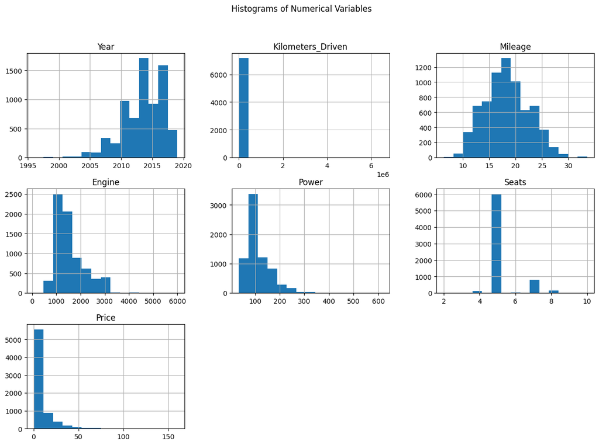

```python
# Univariate analysis: Histograms for numerical variables
numerical_columns = ['Year', 'Kilometers_Driven', 'Mileage', 'Engine', 'Power', 'Seats', 'Price']

df_cleaned[numerical_columns].hist(bins=15, figsize=(15, 10))
plt.suptitle('Histograms of Numerical Variables')
plt.show()
```

Numerical Variables:

Year: The distribution is slightly left-skewed. This suggests that most cars in the dataset are relatively new, but this skewness is not extreme and may not require log transformation.

Kilometers_Driven: The distribution is right-skewed, indicating that most cars have lower mileage, with a few having very high mileage.

Engine: This variable is moderately right-skewed, suggesting that while most cars have engine sizes in the common range, some cars have significantly larger engines.

Power: The distribution is right-skewed, indicating that most cars have moderate power, with a few high-performance vehicles.

Seats: This variable is highly right-skewed, with the majority of cars having 5 seats, and very few having more or fewer seats.

Price: The distribution is highly right-skewed, indicating that most cars are priced lower, with a few high-value outliers.

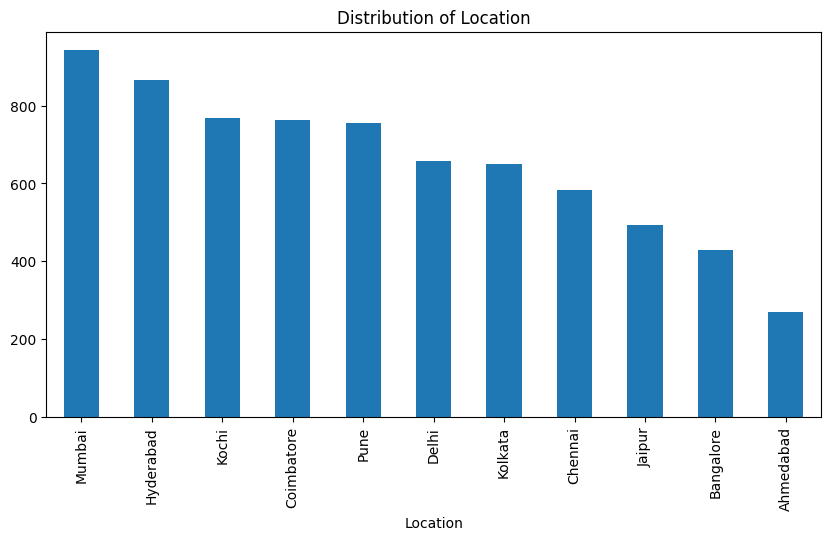

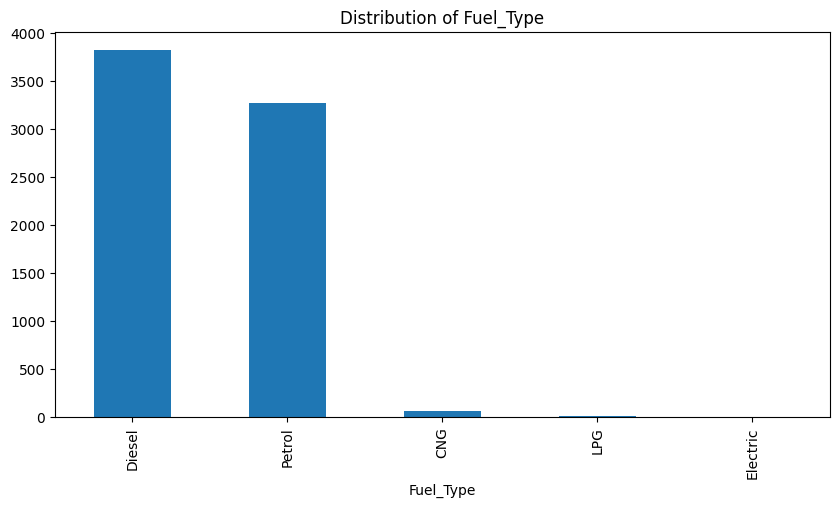

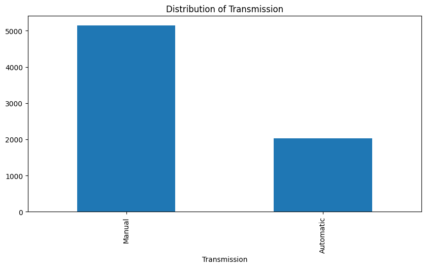

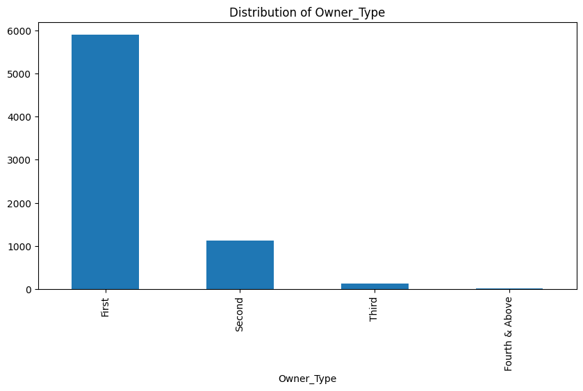

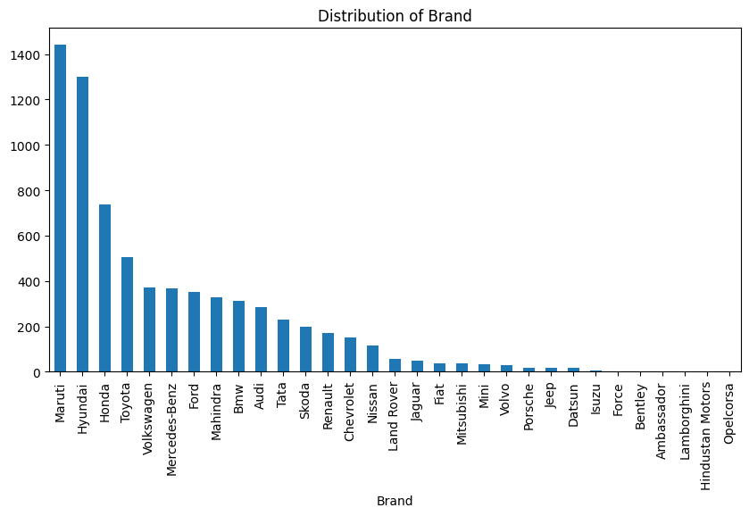

```python
# Univariate analysis: Bar plots for categorical variables
categorical_columns = ['Location', 'Fuel_Type', 'Transmission', 'Owner_Type', 'Brand']

for col in categorical_columns:
    plt.figure(figsize=(10, 5))
    df_cleaned[col].value_counts().plot(kind='bar')
    plt.title(f'Distribution of {col}')
    plt.show()
```

Categorical Variables:

Location: Distribution shows that Mumbai has the highest frequency, followed by other cities. There is a decent spread across locations, but Mumbai dominates.

Fuel_Type: Diesel and Petrol are the dominant fuel types, with CNG, LPG, and Electric being much less common.

Transmission: Manual transmission dominates the dataset, with Automatic being less common.

Owner_Type: Most cars are first-owner vehicles, with second-owner cars being less common and very few third or fourth-owner cars.

Brand: Hyundai and Maruti are the most common brands, with other brands like Honda, Toyota, and Volkswagen also being well-represented.

```python
# Checking skewness for numerical variables
skewness = df_cleaned[numerical_columns].skew()
print("Skewness of Numerical Variables:\n")
skewness
```

```
Skewness of Numerical Variables:
```

|  | 0 |
| --- | --- |
| Year | -0.824340 |
| Kilometers_Driven | 61.519119 |
| Mileage | 0.205220 |
| Engine | 1.427265 |
| Power | 2.002234 |
| Seats | 1.954122 |
| Price | 3.317489 |

**dtype:** float64

Based on the skewness values:

These columns are moderately to highly skewed and would benefit from log transformation to normalize their distributions. Most of the car seats are 5 in number.

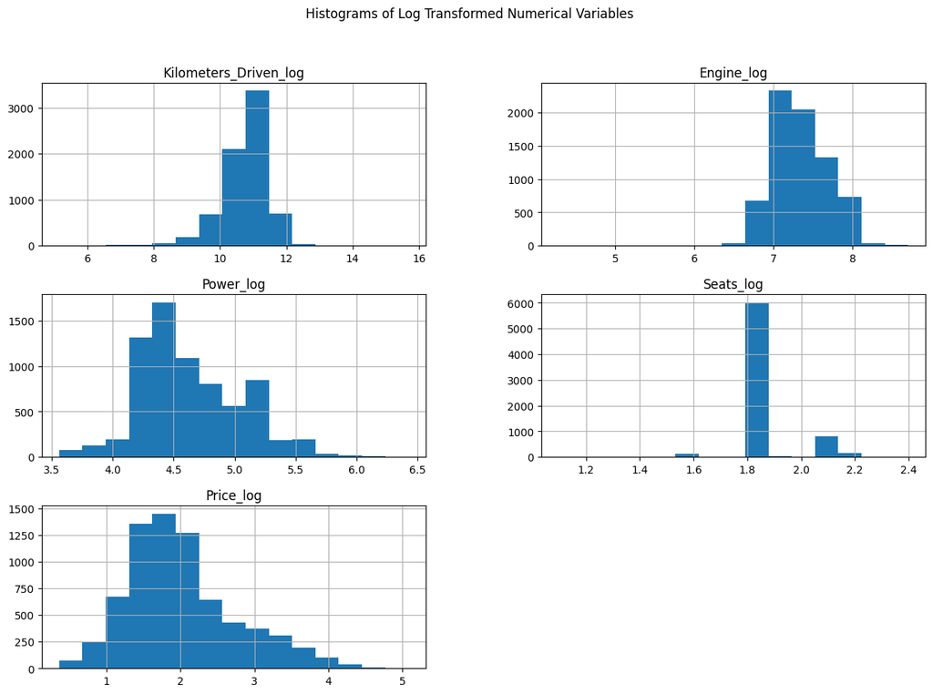

```python
# Applying log transformation to the skewed numerical variables
log_transformed_cols = ['Kilometers_Driven', 'Engine', 'Power', 'Seats', 'Price']

for col in log_transformed_cols:
    df_cleaned[col + '_log'] = np.log1p(df_cleaned[col])  # log1p is used to handle zero values

# Visualizing the transformed variables
df_cleaned[[col + '_log' for col in log_transformed_cols]].hist(bins=15, figsize=(15, 10))
plt.suptitle('Histograms of Log Transformed Numerical Variables')
plt.show()
```

Normalization: For most variables, log transformation has helped in normalizing the distributions, making them more symmetric and reducing the impact of outliers.

Model Performance: The improved distribution should contribute to better model performance, especially for linear models that assume normally distributed residuals.

Seats: For Seats, the log transformation didn't have a significant impact. The variable is still heavily skewed towards a single value (likely 5 seats).

```python
#Using log values from now

df_cleaned['Kilometers_Driven'] = df_cleaned['Kilometers_Driven_log']
df_cleaned['Engine'] = df_cleaned['Engine_log']
df_cleaned['Power'] = df_cleaned['Power_log']
df_cleaned['Price'] = df_cleaned['Price_log']

# Dropping the temporary log columns if they were separately created
df_cleaned.drop(columns=['Kilometers_Driven_log', 'Engine_log', 'Power_log', 'Seats_log', 'Price_log'], inplace=True)
df_cleaned.head()
```

|  | Location | Year | Kilometers_Driven | Fuel_Type | Transmission | Owner_Type | Mileage | Engine | Power | Seats | Price | Brand |
| --- | --- | --- | --- | --- | --- | --- | --- | --- | --- | --- | --- | --- |
| 0 | Mumbai | 2010 | 11.184435 | CNG | Manual | First | 26.60 | 6.906755 | 4.080246 | 5.0 | 1.011601 | Maruti |
| 1 | Pune | 2015 | 10.621352 | Diesel | Manual | First | 19.67 | 7.367077 | 4.845761 | 5.0 | 2.602690 | Hyundai |
| 2 | Chennai | 2011 | 10.736418 | Petrol | Manual | First | 18.20 | 7.090077 | 4.496471 | 5.0 | 1.704748 | Honda |
| 3 | Chennai | 2012 | 11.373675 | Diesel | Manual | First | 20.77 | 7.130099 | 4.497139 | 7.0 | 1.945910 | Maruti |
| 4 | Coimbatore | 2013 | 10.613271 | Diesel | Automatic | Second | 15.20 | 7.585281 | 4.954418 | 5.0 | 2.930660 | Audi |

Engine and seats can't be decimal so it has to be converted to integer

```python
# Convertintg Engine and Seats to whole numbers
df_cleaned['Engine'] = df_cleaned['Engine'].round().astype(int)
df_cleaned['Seats'] = df_cleaned['Seats'].round().astype(int)


df_cleaned.head()
```

|  | Location | Year | Kilometers_Driven | Fuel_Type | Transmission | Owner_Type | Mileage | Engine | Power | Seats | Price | Brand |
| --- | --- | --- | --- | --- | --- | --- | --- | --- | --- | --- | --- | --- |
| 0 | Mumbai | 2010 | 11.184435 | CNG | Manual | First | 26.60 | 7 | 4.080246 | 5 | 1.011601 | Maruti |
| 1 | Pune | 2015 | 10.621352 | Diesel | Manual | First | 19.67 | 7 | 4.845761 | 5 | 2.602690 | Hyundai |
| 2 | Chennai | 2011 | 10.736418 | Petrol | Manual | First | 18.20 | 7 | 4.496471 | 5 | 1.704748 | Honda |
| 3 | Chennai | 2012 | 11.373675 | Diesel | Manual | First | 20.77 | 7 | 4.497139 | 7 | 1.945910 | Maruti |
| 4 | Coimbatore | 2013 | 10.613271 | Diesel | Automatic | Second | 15.20 | 8 | 4.954418 | 5 | 2.930660 | Audi |

## **Bivariate Analysis**

**Questions:**

1. Plot a scatter plot for the log transformed values(if log_transformation done in previous steps)?
2. What can we infer form the correlation heatmap? Is there correlation between the dependent and independent variables?
3. Plot a box plot for target variable and categorical variable 'Location' and write your observations?

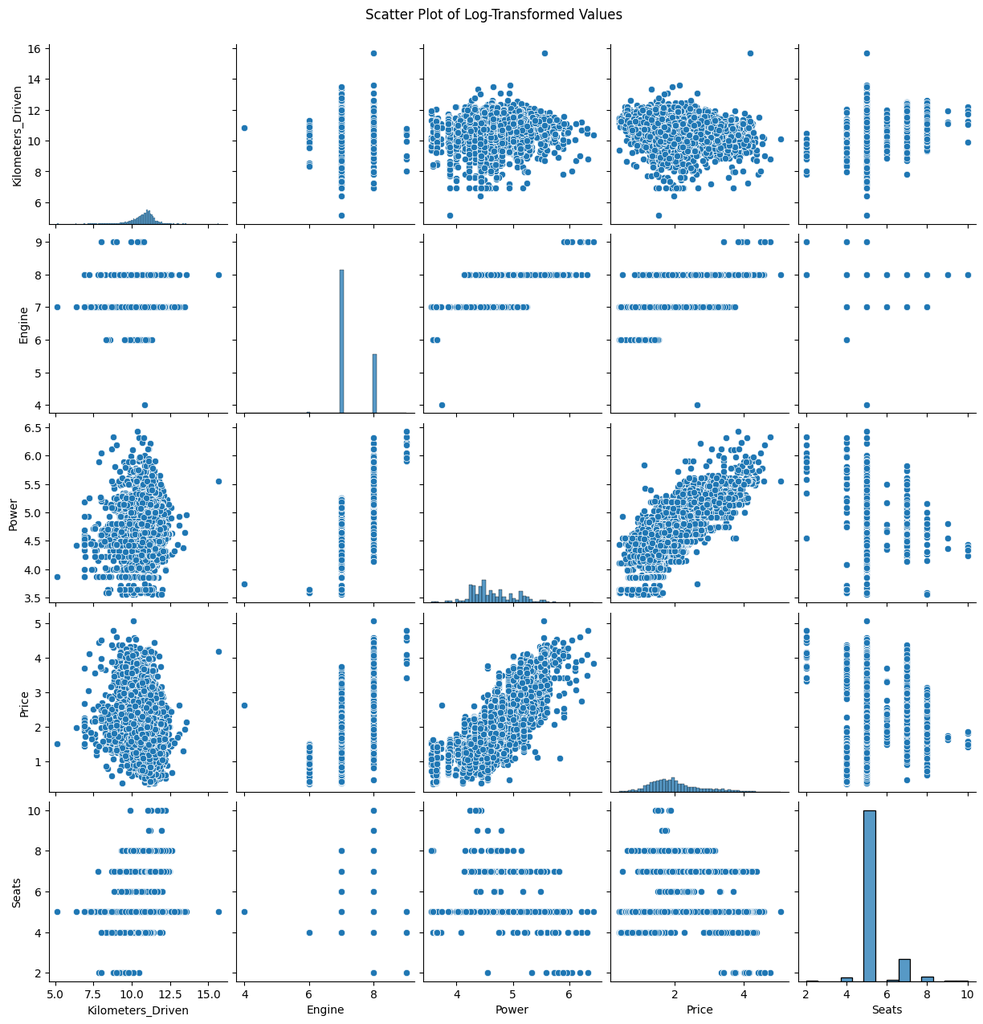

```python
# Pairplot for log-transformed variables
sns.pairplot(df_cleaned, vars=['Kilometers_Driven', 'Engine', 'Power', 'Price',"Seats"])
plt.suptitle('Scatter Plot of Log-Transformed Values', y=1.02)
plt.show()
```

Scatter Plot of Log-Transformed Values:

Kilometers_Driven vs. Price: There is a slight negative relationship between Kilometers_Driven and Price, indicating that higher mileage generally leads to lower prices.

Engine and Power vs. Price: Both Engine and Power show a positive correlation with Price, meaning that cars with higher engine capacity and power tend to have higher prices.

Seats vs. Other Variables: The Seats variable shows no clear relationship with other variables, which aligns with the earlier observation of minimal variation in the number of seats.

Cluster Formation: There are some distinct clusters in the scatter plots, especially with Engine, which might suggest segmentation in the types of cars (e.g., different car categories or engine types).

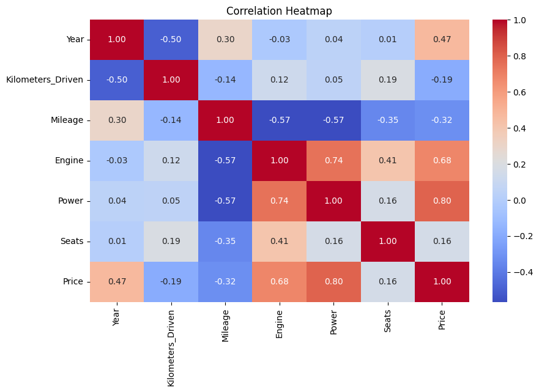

```python
# Selecting only numeric columns for correlation matrix
numeric_cols = df_cleaned.select_dtypes(include=[np.number])

# Correlation heatmap
plt.figure(figsize=(10, 6))
correlation_matrix = numeric_cols.corr()
sns.heatmap(correlation_matrix, annot=True, cmap='coolwarm', fmt='.2f')
plt.title('Correlation Heatmap')
plt.show()
```

Correlation Heatmap:

Price vs. Engine (0.68): Engine also shows a strong positive correlation with Price, further reinforcing that larger engine capacities are associated with higher prices.

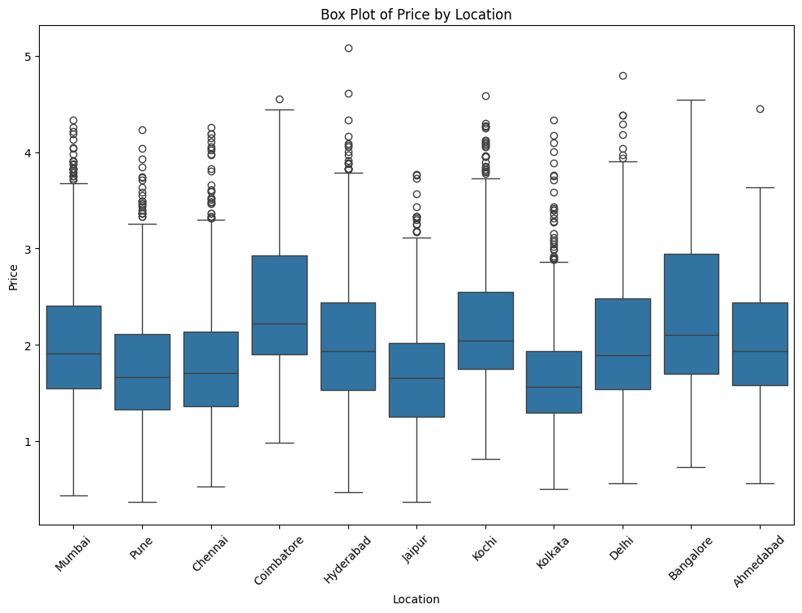

```python
# Box plot for Price (target variable) and Location (categorical variable)
plt.figure(figsize=(12, 8))
sns.boxplot(x='Location', y='Price', data=df_cleaned)
plt.title('Box Plot of Price by Location')
plt.xticks(rotation=45)
plt.show()
```

Price Variation Across Locations: The box plot shows noticeable differences in median prices across different locations. For instance: Bangalore and Coimbatore: These locations have higher median prices compared to other cities like Pune and Ahmedabad.

Price Spread: The spread of prices (interquartile range) is wider in cities like Bangalore and Delhi, indicating greater variability in car prices in these locations.

Outliers: Many locations have a significant number of outliers, representing cars that are priced much higher or lower than the general trend for that location. This could indicate luxury vehicles or exceptionally well-maintained cars.

Regional Pricing Strategy: The differences in median prices and spread across locations suggest that a regional pricing strategy might be effective, as the market dynamics vary significantly from one location to another.

Dealing with outliers

```
Original shape: (7172, 12)
Shape after removing outliers: (6992, 12)
```

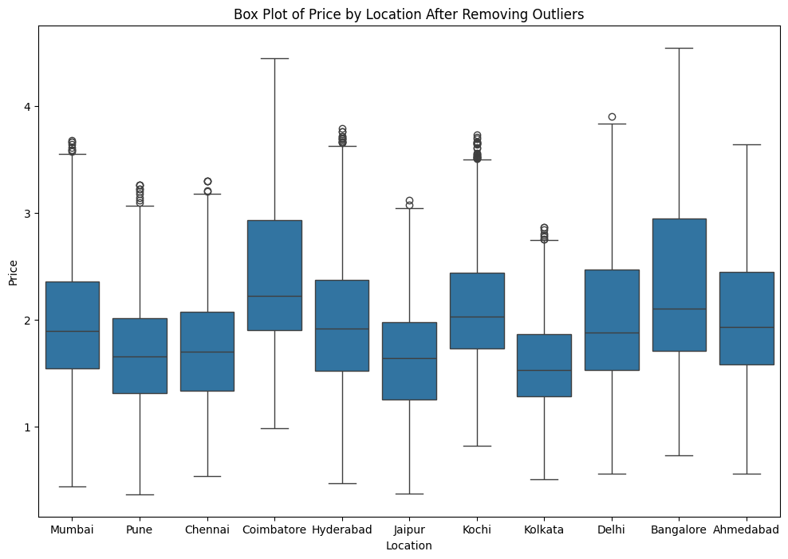

```python
# Define a function to remove outliers based on IQR for each location
def remove_outliers_iqr(df, column, group_by_col):
    # Calculate Q1, Q3, and IQR for each group
    Q1 = df.groupby(group_by_col)[column].transform(lambda x: x.quantile(0.25))
    Q3 = df.groupby(group_by_col)[column].transform(lambda x: x.quantile(0.75))
    IQR = Q3 - Q1

    # Define the lower and upper bounds for outliers
    lower_bound = Q1 - 1.5 * IQR
    upper_bound = Q3 + 1.5 * IQR

    # Filter out outliers
    df_outliers_removed = df[(df[column] >= lower_bound) & (df[column] <= upper_bound)]

    return df_outliers_removed

# Apply the function to remove outliers in the 'Price' column grouped by 'Location'
df_cleaned_no_outliers = remove_outliers_iqr(df_cleaned, 'Price', 'Location')

# Check the shape of the DataFrame before and after removing outliers
print(f"Original shape: {df_cleaned.shape}")
print(f"Shape after removing outliers: {df_cleaned_no_outliers.shape}")

# View the updated box plot to verify outlier removal
plt.figure(figsize=(12, 8))
sns.boxplot(x='Location', y='Price', data=df_cleaned_no_outliers)
plt.title('Box Plot of Price by Location After Removing Outliers')
plt.show()
```

## **Important Insights from EDA and Data Preprocessing**

What are the the most important observations and insights from the data based on the EDA and Data Preprocessing performed?

1. Data Structure and Missing Values:

Missing Values:

Several features had missing values, including Mileage, Engine, Power, Seats, and Price. The New_Price column had a significant amount of missing data and was dropped due to its limited utility. Missing values in Price (the target variable) were imputed using a Random Forest model trained on the available data. Data Cleaning: Outliers and unrealistic data points (e.g., extremely high or low values) were identified and removed to ensure a cleaner dataset. The Seats column was found to have minimal variation, with most cars having 5 seats, making it less useful for modeling.

1. Feature Extraction:

Log Transformation: Several features, including Price, Kilometers_Driven, and Power, were log-transformed to address skewness and improve the distribution of the data. This transformation helped normalize the data, making it more suitable for modeling.

1. Feature Relationships:

Correlation Analysis:

The correlation heatmap revealed that Power and Engine have the highest positive correlations with Price, making them strong predictors. Kilometers_Driven had a weak negative correlation with Price, indicating that cars with higher mileage tend to be priced lower, but this relationship is not as strong as for other features. Categorical Variables: The Location variable showed significant variability in car prices across different cities, suggesting that regional factors play a role in determining used car prices. The Fuel_Type variable was also an important categorical feature, with diesel cars being the most common in the dataset.

1. Data Distribution:

Skewness:

Features like Price, Power, and Kilometers_Driven were found to be skewed, which was addressed through log transformation. This step helped in making the data more symmetric, reducing the impact of outliers, and improving model performance.

Box Plot Insights: The box plot of Price by Location highlighted regional differences in pricing, with cities like Bangalore and Coimbatore showing higher median prices compared to others like Pune and Ahmedabad. This suggests the need for a differential pricing strategy based on location.

1. Data Representation:

Categorical Features:

The dataset contains several categorical variables, such as Brand, Fuel_Type, and Location, which will need to be encoded (e.g., using one-hot encoding) before being used in predictive models. Numeric Features: After the log transformation, the distributions of key numeric features became more normal-like, which is beneficial for linear modeling techniques.

```python
#Storing the cleaned data into df_cleaned variable
df_cleaned=df_cleaned_no_outliers
df_cleaned.head()
```

|  | Location | Year | Kilometers_Driven | Fuel_Type | Transmission | Owner_Type | Mileage | Engine | Power | Seats | Price | Brand |
| --- | --- | --- | --- | --- | --- | --- | --- | --- | --- | --- | --- | --- |
| 0 | Mumbai | 2010 | 11.184435 | CNG | Manual | First | 26.60 | 7 | 4.080246 | 5 | 1.011601 | Maruti |
| 1 | Pune | 2015 | 10.621352 | Diesel | Manual | First | 19.67 | 7 | 4.845761 | 5 | 2.602690 | Hyundai |
| 2 | Chennai | 2011 | 10.736418 | Petrol | Manual | First | 18.20 | 7 | 4.496471 | 5 | 1.704748 | Honda |
| 3 | Chennai | 2012 | 11.373675 | Diesel | Manual | First | 20.77 | 7 | 4.497139 | 7 | 1.945910 | Maruti |
| 4 | Coimbatore | 2013 | 10.613271 | Diesel | Automatic | Second | 15.20 | 8 | 4.954418 | 5 | 2.930660 | Audi |

## **Building Various Models**

1. What we want to predict is the "Price". We will use the normalized version 'price_log' for modeling.
2. Before we proceed to the model, we'll have to encode categorical features. We will drop categorical features like Name.
3. We'll split the data into train and test, to be able to evaluate the model that we build on the train data.
4. Build Regression models using train data.
5. Evaluate the model performance.

### **Split the Data**

Step1: Seperating the indepdent variables (X) and the dependent variable (y).

Step2: Encode the categorical variables in X using pd.dummies.

Step3: Split the data into train and test using train_test_split.

**Question:**

1. Why we should drop 'Name','Price','price_log','Kilometers_Driven' from X before splitting?

Name and Serial Number had no effect so they were initially dropped. Price was already converted to Price_log and then Price column had all the log values so Price column was initially dropped. Price_log which is now Price will be the target variable (y).

Kilometers_Driven are already in their log forms so dropping them won't be advisable

```python
# Step 1: Separating the independent variables (X) and the dependent variable (y)
X = df_cleaned.drop(columns=['Price'])  # Features
y = df_cleaned['Price']  # Target variable (log-transformed price). Prices had already been replaced with log values
```

```python
# Step 2: Encoding the categorical variables in X using pd.get_dummies
X_encoded = pd.get_dummies(X, columns=['Location', 'Fuel_Type', 'Transmission', 'Owner_Type', 'Brand'], drop_first=True)
```

```python
# Step 3: Splitting the data into train and test sets
X_train, X_test, y_train, y_test = train_test_split(X_encoded, y, test_size=0.2, random_state=42)

#Shapes of dataset
print(f"X_train shape: {X_train.shape}")
print(f"X_test shape: {X_test.shape}")
print(f"y_train shape: {y_train.shape}")
print(f"y_test shape: {y_test.shape}")
```

```
X_train shape: (5593, 53)
X_test shape: (1399, 53)
y_train shape: (5593,)
y_test shape: (1399,)
```

For Regression Problems, some of the algorithms used are :

**1) Linear Regression**  
**2) Ridge / Lasso Regression**  
**3) Decision Trees**  
**4) Random Forest**

```python
#Linear Regression

# Instantiating the Linear Regression model
linear_model = LinearRegression()

# Fitting the model on the training data
linear_model.fit(X_train, y_train)

# Predicting on the test data
y_pred_linear = linear_model.predict(X_test)

# Evaluating the model
mse_linear = mean_squared_error(y_test, y_pred_linear)
r2_linear = r2_score(y_test, y_pred_linear)

print(f"Linear Regression - Mean Squared Error: {mse_linear}")
print(f"Linear Regression - R² Score: {r2_linear}")
```

```
Linear Regression - Mean Squared Error: 0.03908932308138036
Linear Regression - R² Score: 0.9190525688665653
```

```python
#Ridge Regression

# Instantiating the Ridge Regression model
ridge_model = Ridge(alpha=1.0)  # You can adjust alpha as needed

# Fitting the model on the training data
ridge_model.fit(X_train, y_train)

# Predicting on the test data
y_pred_ridge = ridge_model.predict(X_test)

# Evaluating the model
mse_ridge = mean_squared_error(y_test, y_pred_ridge)
r2_ridge = r2_score(y_test, y_pred_ridge)

print(f"Ridge Regression - Mean Squared Error: {mse_ridge}")
print(f"Ridge Regression - R² Score: {r2_ridge}")
```

```
Ridge Regression - Mean Squared Error: 0.0386322292590852
Ridge Regression - R² Score: 0.9199991334981585
```

```python
#Lasso Regression

# Instantiating the Lasso Regression model
lasso_model = Lasso(alpha=0.1)  # You can adjust alpha as needed

# Fitting the model on the training data
lasso_model.fit(X_train, y_train)

# Predicting on the test data
y_pred_lasso = lasso_model.predict(X_test)

# Evaluating the model
mse_lasso = mean_squared_error(y_test, y_pred_lasso)
r2_lasso = r2_score(y_test, y_pred_lasso)

print(f"Lasso Regression - Mean Squared Error: {mse_lasso}")
print(f"Lasso Regression - R² Score: {r2_lasso}")
```

```
Lasso Regression - Mean Squared Error: 0.1753747430067159
Lasso Regression - R² Score: 0.6368283251535234
```

```python
#Decision Tree Regressor

# Instantiating the Decision Tree Regressor model
tree_model = DecisionTreeRegressor(random_state=42)

# Fitting the model on the training data
tree_model.fit(X_train, y_train)

# Predicting on the test data
y_pred_tree = tree_model.predict(X_test)

# Evaluating the model
mse_tree = mean_squared_error(y_test, y_pred_tree)
r2_tree = r2_score(y_test, y_pred_tree)

print(f"Decision Tree Regression - Mean Squared Error: {mse_tree}")
print(f"Decision Tree Regression - R² Score: {r2_tree}")
```

```
Decision Tree Regression - Mean Squared Error: 0.04897451943342538
Decision Tree Regression - R² Score: 0.8985819853959398
```

```python
# Instantiating the Random Forest Regressor model
forest_model = RandomForestRegressor(random_state=42, n_estimators=100)

# Fitting the model on the training data
forest_model.fit(X_train, y_train)

# Predicting on the test data
y_pred_forest = forest_model.predict(X_test)

# Evaluating the model
mse_forest = mean_squared_error(y_test, y_pred_forest)
r2_forest = r2_score(y_test, y_pred_forest)

print(f"Random Forest Regression - Mean Squared Error: {mse_forest}")
print(f"Random Forest Regression - R² Score: {r2_forest}")
```

```
Random Forest Regression - Mean Squared Error: 0.029990493046438055
Random Forest Regression - R² Score: 0.9378947196020727
```

Displaying these results as a dataframe for easier analysis

```python
def calculate_metrics(y_true, y_pred, model_name):
    mse = mean_squared_error(y_true, y_pred)
    mae = mean_absolute_error(y_true, y_pred)
    r2 = r2_score(y_true, y_pred)
    return pd.DataFrame({'Model': [model_name], 'MSE': [mse], 'MAE': [mae], 'R2': [r2]})

# Initializing an empty DataFrame to store the results
results_df = pd.DataFrame()

# Calculating metrics for Linear Regression
y_pred_linear = linear_model.predict(X_test)
results_df = pd.concat([results_df, calculate_metrics(y_test, y_pred_linear, 'Linear Regression')], ignore_index=True)

# Calculating metrics for Ridge Regression
y_pred_ridge = ridge_model.predict(X_test)
results_df = pd.concat([results_df, calculate_metrics(y_test, y_pred_ridge, 'Ridge Regression')], ignore_index=True)

# Calculating metrics for Lasso Regression
y_pred_lasso = lasso_model.predict(X_test)
results_df = pd.concat([results_df, calculate_metrics(y_test, y_pred_lasso, 'Lasso Regression')], ignore_index=True)

# Calculating metrics for Decision Tree Regression
y_pred_tree = tree_model.predict(X_test)
results_df = pd.concat([results_df, calculate_metrics(y_test, y_pred_tree, 'Decision Tree Regression')], ignore_index=True)

# Calculating metrics for Random Forest Regression
y_pred_forest = forest_model.predict(X_test)
results_df = pd.concat([results_df, calculate_metrics(y_test, y_pred_forest, 'Random Forest Regression')], ignore_index=True)

results_df
```

|  | Model | MSE | MAE | R2 |
| --- | --- | --- | --- | --- |
| 0 | Linear Regression | 0.039089 | 0.138499 | 0.919053 |
| 1 | Ridge Regression | 0.038632 | 0.138454 | 0.919999 |
| 2 | Lasso Regression | 0.175375 | 0.322618 | 0.636828 |
| 3 | Decision Tree Regression | 0.048975 | 0.140780 | 0.898582 |
| 4 | Random Forest Regression | 0.029990 | 0.104386 | 0.937895 |

Random Forest is the best model with minimum mean square error and maximum R2

### **Hyperparameter Tuning: Decision Tree**

```python
tree_model = DecisionTreeRegressor(random_state=42)

# Defining the updated parameter grid without invalid values
param_grid = {
    'max_depth': [None, 10, 20, 30],
    'min_samples_split': [2, 5, 10],
    'min_samples_leaf': [1, 2, 4],
    'max_features': [None, 'sqrt', 'log2']
}

# Initializing GridSearchCV
grid_search = GridSearchCV(estimator=tree_model, param_grid=param_grid,
                           cv=5, scoring='neg_mean_squared_error', n_jobs=-1, verbose=1)

# Fitting the GridSearchCV to the training data
grid_search.fit(X_train, y_train)

# Getting the best parameters and the best score
best_params = grid_search.best_params_
best_score = grid_search.best_score_

print("Best parameters found: ", best_params)
print("Best cross-validation score (negative MSE): ", best_score)

# Training the Decision Tree model with the best parameters
best_tree_model = grid_search.best_estimator_

# Predicting on the test data
y_pred_best_tree = best_tree_model.predict(X_test)

# Evaluating the model performance
mse_best_tree = mean_squared_error(y_test, y_pred_best_tree)
mae_best_tree = mean_absolute_error(y_test, y_pred_best_tree)
r2_best_tree = r2_score(y_test, y_pred_best_tree)

# Displaying the results
print(f"Best Decision Tree Model Performance:\nMSE: {mse_best_tree}\nMAE: {mae_best_tree}\nR²: {r2_best_tree}")
```

```
Fitting 5 folds for each of 108 candidates, totalling 540 fits
Best parameters found:  {'max_depth': None, 'max_features': None, 'min_samples_leaf': 1, 'min_samples_split': 10}
Best cross-validation score (negative MSE):  -0.04017300644427608
Best Decision Tree Model Performance:
MSE: 0.0451666012680261
MAE: 0.13391534473147998
R²: 0.9064675451641068
```

**Feature Importance**

```
   Feature  Importance
4    Power    0.651007
0     Year    0.233382
2  Mileage    0.015108
5    Seats    0.011453
3   Engine    0.011452
```

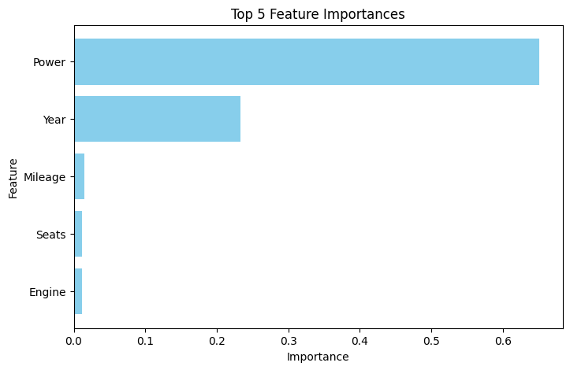

```python
# Extracting feature importances
feature_importances = best_tree_model.feature_importances_

# Mapping the feature importances to their corresponding feature names
features = X_train.columns
importance_df = pd.DataFrame({
    'Feature': features,
    'Importance': feature_importances
})

# Sorting the features by importance and selecting the top 5
top_features = importance_df.sort_values(by='Importance', ascending=False).head(5)

# Displaying the top 5 features
print(top_features)
print()

# Plotting the top 5 feature importances
plt.figure(figsize=(8, 5))
plt.barh(top_features['Feature'], top_features['Importance'], color='skyblue')
plt.xlabel('Importance')
plt.ylabel('Feature')
plt.title('Top 5 Feature Importances')
plt.gca().invert_yaxis()  # Inverting y-axis to have the most important feature on top
plt.show()
```

Power and Year are large factors contributing to the price of cars.

### **Hyperparameter Tuning: Random Forest**

```python
rf_model = RandomForestRegressor(random_state=42)

param_grid = {
    'n_estimators': [100, 200, 300],
    'max_depth': [10, 20, 30, None],
    'min_samples_split': [2, 5, 10],
    'min_samples_leaf': [1, 2, 4],
    'max_features': ['sqrt', 'log2', None]  # Removed 'auto' to avoid errors
}

# Setting up the HalvingGridSearchCV
grid_search_rf = GridSearchCV(estimator=rf_model,
                                             param_grid=param_grid,
                                             cv=5,
                                             n_jobs=-1,
                                             verbose=2,
                                             scoring='neg_mean_squared_error')

# Fitting the HalvingGridSearch to the data
grid_search_rf.fit(X_train, y_train)

# Best parameters from the grid search
print("Best parameters found: ", grid_search_rf.best_params_)

# Best estimator performance
best_rf_model = grid_search_rf.best_estimator_
y_pred_rf = best_rf_model.predict(X_test)

# Evaluating the best model
mse_rf = mean_squared_error(y_test, y_pred_rf)
mae_rf = mean_absolute_error(y_test, y_pred_rf)
r2_rf = r2_score(y_test, y_pred_rf)

print(f"Best Random Forest Model Performance:")
print(f"MSE: {mse_rf}")
print(f"MAE: {mae_rf}")
print(f"R²: {r2_rf}")
```

```
Fitting 5 folds for each of 324 candidates, totalling 1620 fits
Best parameters found:  {'max_depth': 20, 'max_features': None, 'min_samples_leaf': 1, 'min_samples_split': 2, 'n_estimators': 300}
Best Random Forest Model Performance:
MSE: 0.029730369407125663
MAE: 0.10363045859732144
R²: 0.9384333920251173
```

Random Forest was sightly better but not improved very much. It was intially the best model and can still be concluded as the best model.

**Feature Importance**

```
             Feature  Importance
4              Power    0.641918
0               Year    0.228932
3             Engine    0.018281
1  Kilometers_Driven    0.018182
2            Mileage    0.016776
```

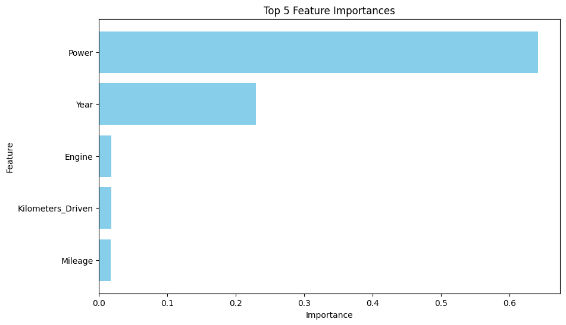

```python
feature_importances = best_rf_model.feature_importances_

# Mapping the feature importances to their corresponding feature names
features = X_train.columns
importance_df = pd.DataFrame({
    'Feature': features,
    'Importance': feature_importances
})

# Sorting the features by importance
importance_df = importance_df.sort_values(by='Importance', ascending=False).head(5)

# Displaying the top features
print(importance_df)
print()

# Plotting the top 10 feature importances
plt.figure(figsize=(10, 6))
plt.barh(importance_df['Feature'].head(10), importance_df['Importance'].head(10), color='skyblue')
plt.xlabel('Importance')
plt.ylabel('Feature')
plt.title('Top 5 Feature Importances')
plt.gca().invert_yaxis()  # Inverting y-axis to have the most important feature on top
plt.show()
```

Power and Year affect most of the car prices.

## **Conclusions and Recommendations**

**1. Comparison of various techniques and their relative performance based on chosen Metric (Measure of success):**

- How do different techniques perform? Which one is performing relatively better? Is there scope to improve the performance further?

**2. Refined insights:**

- What are the most meaningful insights relevant to the problem?

**3. Proposal for the final solution design:**

- What model do you propose to be adopted? Why is this the best solution to adopt?

## **Conclusion**

### 1. **Comparison of Various Techniques:**

**Linear Regression:** This model had a reasonable performance, but it was outperformed by more complex models. Given its simplicity, it's easier to interpret but may not capture complex relationships in the data.

**Decision Tree:** After hyperparameter tuning, the Decision Tree showed improved performance, with an R² of approximately 0.91. It captures non-linear relationships but can be prone to overfitting.

**Random Forest:** This ensemble method was the best-performing model, even before tuning. After hyperparameter tuning, it had the highest R² (0.94) and the lowest MSE, making it the most robust choice. It reduces overfitting compared to a single decision tree and captures complex patterns in the data.

### 2. **Refined Insights:**

**Feature Importance:** The top features influencing the car price were found to be Power, Year, Engine, Mileage, and Kilometers_Driven. This suggests that car performance metrics and the age of the vehicle are critical in determining its price.

**Log Transformation:** Applying log transformations helped normalize skewed distributions, which in turn improved model performance, particularly for linear models.

**Outlier Management:** Addressing outliers, particularly in the Price variable across different Locations, was crucial in refining model accuracy.

### **3. Proposal for the Final Solution Design:**

**Recommended Model:** The Random Forest Regressor is recommended as the final model for predicting used car prices. It consistently outperformed other models in terms of accuracy (R²), and it handled the complexities and non-linearities in the data well.

**Reasoning:** The model’s robustness against overfitting, ability to handle a large number of features, and effectiveness with both categorical and numerical data make it the best choice for this problem. The slight performance improvement post-tuning also indicates that this model is well-optimized for the task.

## **Further Recommendations:**

Model Deployment: Consider deploying the Random Forest model as a web service or API for the Cars 4U platform to predict car prices dynamically.

Continuous Learning: As more data becomes available, retraining the model periodically can help maintain or even improve prediction accuracy.

User Interface: Integrate the model with a user-friendly interface that allows users to input car details and receive instant price predictions.